# Introduction - Generation of the dataset for the illustrative example

Theophanis Tsandilas and Géry Casiez

For transparency purposes, we present the simulation parameters used to generate the dataset of the introduction’s illustrative example.

**We emphasize:** this example was chosen to demonstrate how the inflated Type I error rates of ART can manifest in practice. In this scenario, ART yields very low *p-*values, whereas other methods (including the ground-truth methods) show no evidence for the corresponding effects. However, in other scenarios (and with different random seeds), ART may produce correct conclusions or exhibit less pronounced problems.

### Preliminary

Let us first import all required libraries and code we use.

```r
# This file includes functions for generating experimental datasets for target distributions
source("illustrative-example-utils.R")

library(ggplot2)
library(kableExtra)
library(gridExtra)
library(tidyverse)
```

### Setting simulation parameters

We first set the parameters of the experimental design: $4 \times 3$ within-subjects with 24 participants. The first factor (X1) represents the task *Difficulty*, while the second factor (X2) represents the *Technique*.

```r
# We simulate a design with two factors. The first (X1: Difficulty) has 4 levels, and the second (X2: Technique) has 3 levels.
nlevels = c(4, 3)

# Both factors are within-subject (repeated-measures)
within = c(1, 1)

# 24 participants
n = 24
```

We then set the distribution parameters for Time measure. We use a log-normal distribution with parameters $\sigma = 0.6$ (`sigma_e` in our code) and a target mean for responses $m = 1.4$. We set the between-participant variability to $\sigma_s = 0.4$, and the magnitude of effects to $a_1 = 2$, $a_2=0$, and $a_{12}=0$. This means that there is only an effect of *Difficulty* (first factor). For an explanation of these parameters, see our article’s [method section](https://www.journalovi.org/2024-tsandilas-ranktransforms/#methodology).

```r
# Distribution parameters for the Time measure (log-normal)
params_lnorm  <- list(sigma_s = 0.4, sigma_e = 0.6, mean_target = 1.4)
# Setting the magnitude of effects. There is only an effect on X1: Difficulty.
coeffs_lnorm <- c("X1"=2, "X2"=0, "X1:X2"=0)

# Set the random seed
set.seed(415)
# And simulate a log-normal distribution
df_lnorm <- simulate_response(
  nlevels, within, n, coeffs_lnorm,
  family = "lnorm",
  params = params_lnorm
)

# Let's only keep two decimal digits
df_lnorm$Y = round(df_lnorm$Y, digits = 2)
```

Similarly, we set the distribution parameters of the *Perceived Efficiency* measure: ordinal with 5 levels. It is derived from a normal distribution with standard deviation $\sigma=1$ (`sigma_e` in our code) and an overall mean of $m = 2.5$. We set the between-participant variability to $\sigma_s = 0.5$, while all effects are null.

```r
# Distribution parameters for the measure Perceived Efficiency (ordinal with 5 levels)
params_ordinal <- list(sigma_s = 0.5, sigma_e = 1, thresholds = c(0.1, 0.4, 1, 2), mean_target = 2.5)

# Setting the magnitude of effects. All effects are null.
coeffs_ordinal <- c("X1"=0, "X2"=0, "X1:X2"=0)

# Set the random seed
set.seed(230)
# And simulate an ordinal distribution (single Likert item)
df_ordinal <- simulate_response(
  nlevels, within, n, coeffs_ordinal,
  family = "likert",
  params = params_ordinal
)
```

### Formatting the dataset

Finally, we merge the two data frames into one and rename the corresponding data variables.

```r
# Create the experimental data with the appropriate column names and values
labels = c("inefficient", "somewhat inefficient", "neutral", "somewhat efficient", "efficient")
df <- data.frame(
  Participant = df_lnorm$subject,
  Difficulty = recode(df_lnorm$X1, "A1" = "Level1", "A2" = "Level2","A3" = "Level3", "A4" = "Level4"),
  Technique = recode(df_lnorm$X2, "B1" = "A", "B2" = "B","B3" = "C"),
  Time = df_lnorm$Y,
  Perceived_Efficiency = factor(df_ordinal$Y, levels = 1:5, labels = labels, ordered = TRUE)
)
```

We present our dataset with a table:

```r
kbl(df, booktabs = TRUE) %>% kable_styling(font_size=14) %>% kable_paper(position = "center") %>% scroll_box(height = "170px")
```

| Participant | Difficulty | Technique | Time | Perceived_Efficiency |
| --- | --- | --- | --- | --- |
| s1 | Level1 | A | 0.18 | somewhat efficient |
| s1 | Level2 | A | 0.52 | efficient |
| s1 | Level3 | A | 2.05 | efficient |
| s1 | Level4 | A | 1.48 | somewhat efficient |
| s1 | Level1 | B | 0.27 | efficient |
| s1 | Level2 | B | 0.85 | efficient |
| s1 | Level3 | B | 1.80 | efficient |
| s1 | Level4 | B | 1.93 | efficient |
| s1 | Level1 | C | 0.19 | efficient |
| s1 | Level2 | C | 0.38 | efficient |
| s1 | Level3 | C | 1.17 | efficient |
| s1 | Level4 | C | 1.70 | somewhat efficient |
| s2 | Level1 | A | 0.23 | efficient |
| s2 | Level2 | A | 0.64 | efficient |
| s2 | Level3 | A | 1.12 | efficient |
| s2 | Level4 | A | 3.51 | efficient |
| s2 | Level1 | B | 0.17 | efficient |
| s2 | Level2 | B | 0.47 | efficient |
| s2 | Level3 | B | 1.08 | efficient |
| s2 | Level4 | B | 4.19 | efficient |
| s2 | Level1 | C | 0.09 | efficient |
| s2 | Level2 | C | 0.52 | somewhat efficient |
| s2 | Level3 | C | 0.96 | efficient |
| s2 | Level4 | C | 0.93 | efficient |
| s3 | Level1 | A | 0.86 | somewhat efficient |
| s3 | Level2 | A | 4.30 | somewhat efficient |
| s3 | Level3 | A | 3.63 | efficient |
| s3 | Level4 | A | 6.70 | somewhat efficient |
| s3 | Level1 | B | 2.63 | efficient |
| s3 | Level2 | B | 4.52 | somewhat efficient |

[output cut: 258 more lines]

### Plotting

We also plot our data to observe the main trends.

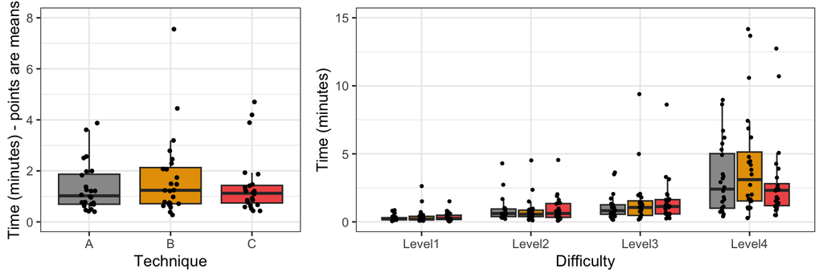

```r
# Display the data
cbPalette <- c("#999999", "#E69F00", "#F15854")

p1 <- (df %>%  group_by(Participant,Technique) %>%
summarise(Time = mean(Time), .groups="drop") %>%
        ggplot(aes(x = Technique, y = Time, fill = Technique)) +
        geom_boxplot(outlier.shape = NA) +
        ylab("Time (minutes) - points are means") +
        ylim(0, 8) +
        geom_jitter(shape=20, position=position_jitter(0.1)) +
        theme_bw() + theme(legend.position = "none")) + scale_fill_manual(values=cbPalette)

p2 <- (df %>%  group_by(Participant,Difficulty,Technique) %>%
        summarise(Time = mean(Time), .groups="drop") %>%
        ggplot(aes(x = Difficulty, y = Time, fill = Technique)) +
        geom_boxplot(outlier.shape = NA) +
        ylab("Time (minutes)") +
        ylim(0, 15) +
        geom_point(size = 0.7, position=position_jitterdodge(0.1)) +
        theme_bw() + theme(legend.position = "none")) +
        scale_fill_manual(values=cbPalette)

grid.arrange(p1, p2, nrow = 1, widths = c(1.5, 2.5))
```

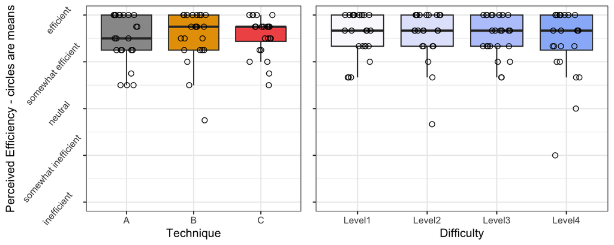

```r
dd1 <- df %>%  group_by(Participant,Technique) %>% summarise(Perceived_Efficiency = mean(as.integer(Perceived_Efficiency)), .groups="drop")

p3 <- (dd1 %>%
        ggplot(aes(x = Technique, y = Perceived_Efficiency, fill = Technique)) +
        geom_boxplot(outlier.shape = NA) +
        ylab("Perceived Efficiency - circles are means") +
        scale_y_continuous(breaks = 1:5, limits = c(1,5), labels=levels(df$Perceived_Efficiency)) +
        geom_jitter(shape=1, position=position_jitter(0.2,0), size = 2) +
        theme_bw() + theme(legend.position = "none")) + scale_fill_manual(values=cbPalette) +
        theme(axis.text.y=element_text(angle=50, hjust=0.7))

dd2 <- df %>%  group_by(Participant,Difficulty) %>% summarise(Perceived_Efficiency = mean(as.integer(Perceived_Efficiency)), .groups="drop")

diffPalette <- c("#f9f9fd", "#e2e6fa", "#bacafb", "#99b9f9")
p4 <- (dd2 %>%
        ggplot(aes(x = Difficulty, y = Perceived_Efficiency, fill = Difficulty)) +
        geom_boxplot(outlier.shape = NA) + ylim(1,5)+
        geom_jitter(shape=1, position=position_jitter(0.2,0), size = 2) +
        theme_bw() + theme(legend.position = "none")) + scale_fill_manual(values=diffPalette) +
        theme(axis.title.y=element_blank(), axis.text.y=element_blank())

grid.arrange(p3, p4, nrow = 1, widths = c(2, 2))
```